# Andmete väärtus tööjõukulude põhjal

Andres Võrk

Visand 2024-02-07

```r
library(dplyr)
library(DT)
library(readxl)
```

## Sissejuhatus

Käesolev dokument kirjeldab meetodit, kuidas tööjõukulude põhjal hinnata andmetesse tehtud investeeringute väärtust. Metoodika aluseks on Corrado et al (2022), Bugge, Amegble, Sinclair (2023), Statistics Canada (2019a, 2019b) ja Goodridge, Haskel ja Edquist (2021) lähenemine.

Andmeid ja andmebaase võivad ettevõtted toota ning kasutada ise või osta ja müüa turul. Turul müüdavad andmed ja andmebaasid on teoreetiliselt hinnatud turuhinnaga (tehingu väärtusega). Ideaalis võiks seda informatsiooni küsida ettevõtetelt, kuid praegu Eestis selle kohta puudub info. Andmed ja andmebaasid, mida kasutatakse ettevõtte enda poolt peaks hindama tootmiskulude alusel, kaasa arvatud hinnanguline kapitalitulu. Et meil puudub teave andmete ja andmebaaside turumüügi kohta, siis on kõigi andmete tootmine, olgu siis turumüügiks või ise kasutamiseks hinnatud tootmiskulude alusel.

Corrado et al (2022) on niinimetatud kulupõhine lähenemine, kus eeldatakse, et investeeringud andmetesse peavad olema vähemalt nii suure väärtusega, kui on nende soetamiseks tehtud kulud, mis kajastuvad peamiselt läbi tööjõukulude.

Metoodika eelduseks on see, et andmete soetusväärtus sõltub tööjõukulust, vahetarbimisest, kapitalikulu (sh kasum) ja netomaksudest.

$$Soetusväärtus = Tööjõukulu +
Vahetarbimine + Kapitalikulu + Netomaksud$$

Esimese sammuna leitakse tööjõukulu, kui andmetega tegelevate töötajate täisajale taandatud arv korda nende tööjõutasu.

$$Tööjõukulu = Töötajate arv×Palk ×
Andmetega töötamise aja osakaal$$

Praktikas eeldatakse lihtsustatult, et andmete soetusväärtus on proportsionaalne tööjõukuluga. Seega skaleeritakse tööjõukulud üles teguriga, mis kajastab teisi komponente (nn blow-up factors).

$$Soetusväärtus = Tööjõukulu ×
Skaleerimistegur$$

Taoline lähenemine eeldab detailsete andmete olemasolu töötajate arvu ja nende töötasu kohta ametialade ja tegevusalade lõikes. Samuti on vaja teha eeldusi (või püüda leida seda küsitlusuuringutest), kui suure osa tööajast kulub töötamisele andmetega selliselt, et tekivad uued andmebaasid või uued andmepõhised otsustusmudelid. Viimaks on vaja anda hinnang teiste kulude kohta, mis tavaliselt võetakse ettevõtlusstatistikast.

## Kasutatavad andmed

Me kasutame andmetena Statistikaameti poolt kokku pandud keskmise palga andmeid ametialade lõikes, mis tugineb TÖRi andmetele. Vt https://www.stat.ee/et/avasta-statistikat/valdkonnad/tooelu/palk-ja-toojoukulu

Alljärgnevalt on toodud arvutuste näide 2022. aasta andmete põhjal.

```r
# Load the readxl package
library(readxl)

# URL of the Excel file
url <- "https://www.stat.ee/sites/default/files/2023-03/palgarakendus_kodulehele_2022_kv1234.xlsx"
# Destination file path
destfile <- "data2022.xlsx"
# Download the file
download.file(url, destfile, mode = "wb")

# Read the 'amet' sheet from the downloaded Excel file
data2022kv <- read_excel(destfile, sheet = "amet") %>% select(AMET, starts_with("arv_taiskohaga"), starts_with("keskmine_"))

#Averages
tooandjamaksud = 0.338 #sotsiaalmaks ja töötuskindlustusmakse

data2022 <- data2022kv %>%
  #Average number of employees and wages
  mutate(tootajadkuus = rowMeans(select(., arv_taiskohaga_2022_kv1, arv_taiskohaga_2022_kv2, arv_taiskohaga_2022_kv3,
                                        arv_taiskohaga_2022_kv4), na.rm = TRUE), #kvartali lõppude keskmine
         palgafond_kv1 = arv_taiskohaga_2022_kv1*keskmine_2022_kv1, #see on kvartali kuu lõpu seisuga palgafond
         palgafond_kv2 = arv_taiskohaga_2022_kv2*keskmine_2022_kv2,
         palgafond_kv3 = arv_taiskohaga_2022_kv3*keskmine_2022_kv3,
         palgafond_kv4 = arv_taiskohaga_2022_kv4*keskmine_2022_kv4) %>%
  mutate(temp1 = rowSums(select(., palgafond_kv1, palgafond_kv2, palgafond_kv3, palgafond_kv4),na.rm = TRUE)) %>%
  mutate(temp2 = rowSums(select(., arv_taiskohaga_2022_kv1, arv_taiskohaga_2022_kv2, arv_taiskohaga_2022_kv3,
                                arv_taiskohaga_2022_kv4), na.rm = TRUE)) %>%
  mutate(keskmpalkkuus = temp1/temp2,
         toojoukuluaastas = tootajadkuus * keskmpalkkuus *12 * (1+ tooandjamaksud))  %>%
  select(AMET, tootajadkuus, keskmpalkkuus,toojoukuluaastas)

#hist(data2022$keskmpalkkuus, breaks = 100)
#hist(data2022$tootajadkuus, breaks = 100)
summary(data2022)
```

```
##       AMET       tootajadkuus     keskmpalkkuus    toojoukuluaastas
##  Min.   :1111   Min.   :   20.0   Min.   : 657.2   Min.   :   293030
##  1st Qu.:2620   1st Qu.:  206.4   1st Qu.:1187.6   1st Qu.:  4715744
##  Median :4120   Median :  499.2   Median :1524.0   Median : 12915976
##  Mean   :4752   Mean   : 1153.4   Mean   :1690.5   Mean   : 30967156
##  3rd Qu.:7232   3rd Qu.: 1442.5   3rd Qu.:2007.1   3rd Qu.: 34922998
##  Max.   :9629   Max.   :17175.8   Max.   :5278.8   Max.   :499573067
```

## Kasutatavad eeldused

Järgmisena peame tegema eelduse, millised ametid panustavad andmete ja andmebaaside loomisse.

Näiteks eeldused, mida oma ettekandes näitasid Bugge jt (2023)

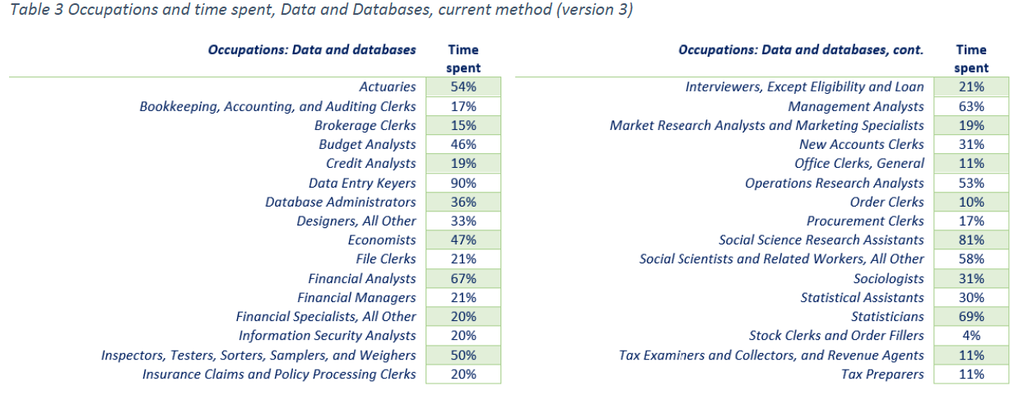

Example 1

Meie eeldused on tehtud eraldi failis.

```r
#timeshare <- read_excel(path = "../andmed/eeldusedajakohta.xlsx")
timeshare <- read_excel(path = "eeldusedajakohta.xlsx")
```

```r
datatable(timeshare %>% filter(timecan2023>0 | timecorrado2022>0) %>% select(iscocode, name_ee, timecan2023, timecorrado2022),
          options = list(scrollX = TRUE, scrollY = '400px'))
```

|  | iscocode | name_ee | timecan2023 | timecorrado2022 |
| --- | --- | --- | --- | --- |
| 1 | 1211 | Finantsjuhid | 21 | 21 |
| 2 | 1346 | Finantsvahendus- ja kindlustusteenuste juhid | 21 | 21 |
| 3 | 2111 | Füüsikud ja astronoomid | 0 | 10 |
| 4 | 2113 | Keemikud | 0 | 10 |
| 5 | 2114 | Geoloogid ja geofüüsikud | 0 | 10 |
| 6 | 2120 | Matemaatikud, aktuaarid ja statistikud | 54 | 10 |
| 7 | 2131 | Bioloogid, botaanikud, zooloogid jms tippspetsialistid | 0 | 10 |
| 8 | 2132 | Põllumajanduse, metsanduse ja kalanduse nõuandjad | 0 | 10 |
| 9 | 2133 | Keskkonnakaitse tippspetsialistid | 0 | 10 |
| 10 | 2141 | Tööstus- ja tootmisinsenerid | 0 | 10 |

[output cut: 54 more lines]

Tööjõukulud kokku, mis läks andmetega tegelemise ajale

```r
df <- data2022 %>% left_join(timeshare, by = c("AMET" = "iscocode"))

#Kui jäävad tegevusalad, siis muutub see vektoriks
laborcost <-  df %>%  summarise(timecost = sum(toojoukuluaastas*timecan2023/100) / 1000000) %>% as.numeric() #in million

print(laborcost)
```

```
## [1] 403.019
```

miljonites eurodes

## Muude kulude juurde lisamine

Skaleerimisfaktorid tuletatakse lihtsalt kui tööjõukulude osakaal lisandväärtuses (?) erinevates majandusharudes. Corrado et al 2022 kasutavad selleks tegevusvaldkondade J 62 “Programmeerimine, konsultatsioonid jms tegevused” ja J 63 “Infoalane tegevus” ettevõtete majandustegevuse näitajaid. Täiendavalt eeldavad nad, et tegevusalasisene vahetarbimine (üks IT ettevõte ostab teiselt IT ettevõttelt) on nendes sektorites lausa 50% ja seetõttu topeltarvestuse vältimiseks on see osa välja jäetud. Eesti puhul saab skaleerimisfaktorid leida ettevõtete majandusnäitajate andmestikust (Statistikaameti andmebaasi tabel EM001 “Ettevõtete majandusnäitajad”). Nii moodustasid näiteks 2022. aastal tegevusalal J62 “Programmeerimine, konsultatsioonid jms tegevused” ja J63 “Infoalane tegevus” tööjõukulud müügitulust 29% ehk skaleerimisfaktor oleks ca 3.5. Kui eeldada, et pool sisseostetud kuludest kategooriates “Müügi eesmärgil ostetud kaubad, kinnisvara ja teenused ja”“Muud ostetud teenused” on tehtud omakorda IKT sektorist, siis moodustaksid tööjõukulud 42% omatoodangust, mis teeks skaleerimisfaktoriks 2.4. Saadud tulemus on sarnane sellele, mida Corrado et al kasutasid oma töös: Suurbritannia 2.1, Prantsusmaa 2.2, Saksamaa 2.3, Hispaania 2.4, Rootsi 2.8 ja Itaalia 3.4.

```r
query = '{"query": [
    {
      "code": "Näitaja",
      "selection": {
        "filter": "item",
        "values": [ "V12110", "CUB_C_100_110_120", "CUB_C_345_350", "V13310"]
      }
    },
    {"code": "Tegevusala",
      "selection": {
        "filter": "item",
        "values": ["J62","J63"]
      }
    },
    {
      "code": "Tööga hõivatud isikute arv",
      "selection": {
        "filter": "item",
        "values": ["TOTAL"]
      }
    },
    {
      "code": "Vaatlusperiood",
      "selection": {
        "filter": "item",
        "values": ["2020","2021","2022"]
      }
    }
  ],
  "response": {
    "format": "csv"
  }
}'


library(rsdmx)
library(XML)
library(httr)
library(jsonlite)


costdata <- content(POST("https://andmed.stat.ee/api/v1/et/stat/EM001",
                            body = query, encode = "json"),
                       type = "text/csv",
                       encoding = "UTF-8") %>%
      as.data.frame()
datatable(costdata, options = list(scrollX = TRUE, scrollY = '400px'))
```

|  | Näitaja | Tegevusala | Kokku 2020 | Kokku 2021 | Kokku 2022 |
| --- | --- | --- | --- | --- | --- |
| 1 | Müügitulu, tuhat eurot | Programmeerimine, konsultatsioonid jms tegevused | 1805927.9 | 2504283.6 | 3832206 |
| 2 | Müügitulu, tuhat eurot | Infoalane tegevus | 300105.3 | 388203.2 | 491304.5 |
| 3 | Müügi eesmärgil ostetud kaubad, kinnisvara ja teenused, tuhat eurot | Programmeerimine, konsultatsioonid jms tegevused | 28223.2 | 43336.5 | 27230 |
| 4 | Müügi eesmärgil ostetud kaubad, kinnisvara ja teenused, tuhat eurot | Infoalane tegevus | 2856.1 | 1612.7 | 2420.2 |
| 5 | Muud ostetud teenused, tuhat eurot | Programmeerimine, konsultatsioonid jms tegevused | 736676.5 | 1375697.5 | 2513576.7 |
| 6 | Muud ostetud teenused, tuhat eurot | Infoalane tegevus | 125205.7 | 166158.6 | 224744.6 |
| 7 | Tööjõukulud, tuhat eurot | Programmeerimine, konsultatsioonid jms tegevused | 679830.5 | 823521.4 | 1096322 |
| 8 | Tööjõukulud, tuhat eurot | Infoalane tegevus | 97518.2 | 103829.8 | 144769.3 |

```r
#2022 aasta põhjal
costs <- costdata %>% group_by(Näitaja) %>%
  summarise(expenditure = sum(`Kokku 2022`))

blowupfactor = (costs$expenditure[costs$Näitaja == "Müügitulu, tuhat eurot"] -
   0.5*costs$expenditure[costs$Näitaja == "Müügi eesmärgil ostetud kaubad, kinnisvara ja teenused, tuhat eurot"]-
   0.5*costs$expenditure[costs$Näitaja == "Muud ostetud teenused, tuhat eurot"]) / costs$expenditure[costs$Näitaja == "Tööjõukulud, tuhat eurot"]


blowupfactor
```

```
## [1] 2.3685
```

Korrutades kokku arvestuslikud tööjõukulud andmetele ja muude kulude suurendamisteguri, saame kokku hinnangulised investeeringud andmetesse ühel konkreetsel aastal.

Tulemus miljonit eurot:

```r
laborcost * blowupfactor
```

```
## [1] 954.5504
```

Võrdluseks, ESA andmetel on kulutused teadus- ja arendustegevusele 2022. aastal 641,74 miljonit eurot. (https://www.stat.ee/et/avasta-statistikat/valdkonnad/infotehnoloogia-innovatsioon-ja-teadus-arendustegevus/teadus-ja-arendustegevus)

## Järgmised sammud

Andmete osas tegevusalade lõikes:

- paluda ESAl välja arvutada ise kohe kogu tööjõukulu aastas kokku ISCO ja tegevusala (EMTAK 1) kaupa, sh TVLide kulu. Kui töötajate arvu ja keskmist palka ei näita, siis ei teki probleeme ilmselt ka väikeste valimitega
- läbipaistvuse huvides oleks parem saada tegevusalade lõikes töölepinguga töötajate arv ja keskmine palk, TVL lepinguga töötajate arv ja keskmine töötasu ja ise välja arvutada tegevusalade lõikes

Eelduste osas:

- teha korralikum tabel, kus eri autorite eeldused eri veerus. Probleemiks on see, et kõik ei too välja selgelt ISCO koode.
- testida neid eeldusi eesti valdkonnaekspertide peal

## Kasutatud kirjandus

Brenda Bugge (Statistics Canada), Koami Amegble (Statistics Canada) and Amanda Sinclair (Statistics Canada) “Estimation of Investment in and Stock of Data in the Canadian System of National Accounts”, ettekanne konverentsil IARIW-CIGI Conference November 2-3, 2023

Corrado, C., Haskel, J., Iommi, M., & Jona-Lasinio, C. (2022) Measuring data as an asset: Framework, methods and preliminary estimates OECD. Economics Department Working Papers No. 1731 https://read.oecd.org/10.1787/b840fb01-en?format=pd

Statistics Canada (2019a). Measuring investment in data, databases and data science: Conceptual framework. https://www150.statcan.gc.ca/n1/pub/13-605-x/2019001/article/00008-eng.htm

Statistics Canada (2019b). The value of data in Canada: Experimental estimates. https://www150.statcan.gc.ca/n1/pub/13-605-x/2019001/article/00009-eng.ht